# Seed Placement Strategies for SNIC

## Loading a working tile

```r
data_dir <- system.file("S2-20LMR", package = "snic", mustWork = TRUE)
band_files <- file.path(
  data_dir,
  c(
    "S2_20LMR_B02_20220630.tif",
    "S2_20LMR_B04_20220630.tif",
    "S2_20LMR_B08_20220630.tif",
    "S2_20LMR_B12_20220630.tif"
  )
)
s2 <- rast(band_files)
s2_demo <- aggregate(s2, fact = 8)
```

Different seed layouts change how SNIC explores the image. The helper functions in `snic_grid` generate coordinate matrices that can be supplied directly to `snic()`.

```r
spacing <- 28L
set.seed(42)
seeds_rect <- snic_grid_rect(s2_demo, spacing = spacing)
seeds_diamond <- snic_grid_diamond(s2_demo, spacing = spacing)
seeds_hex <- snic_grid_hexagon(s2_demo, spacing = spacing)
seeds_random <- snic_grid_random(s2_demo, spacing = spacing)

vapply(
  list(rectangular = seeds_rect,
       diamond = seeds_diamond,
       near_isotropic = seeds_hex,
       random = seeds_random),
  nrow,
  integer(1)
)
```

```
#>    rectangular        diamond near_isotropic         random
#>             12              8              8             12
```

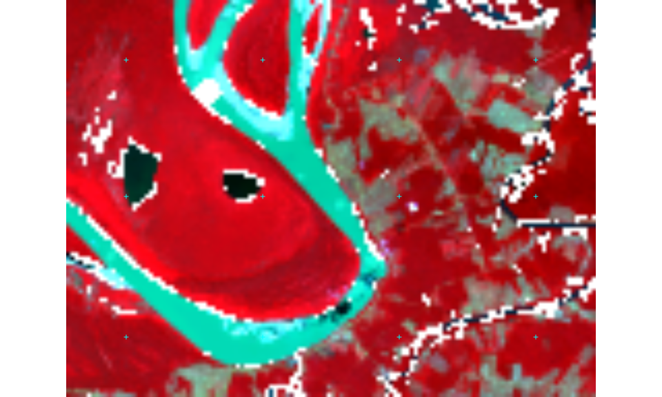

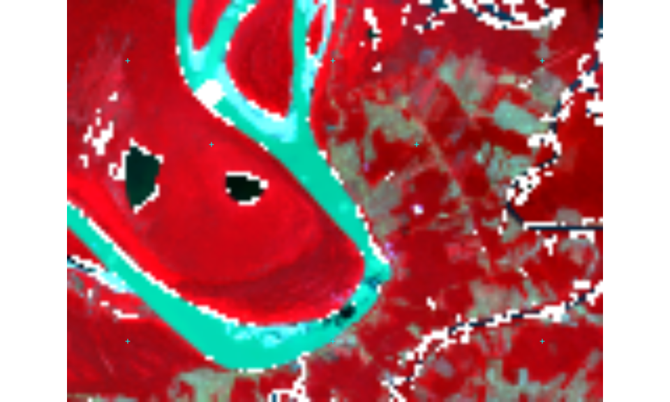

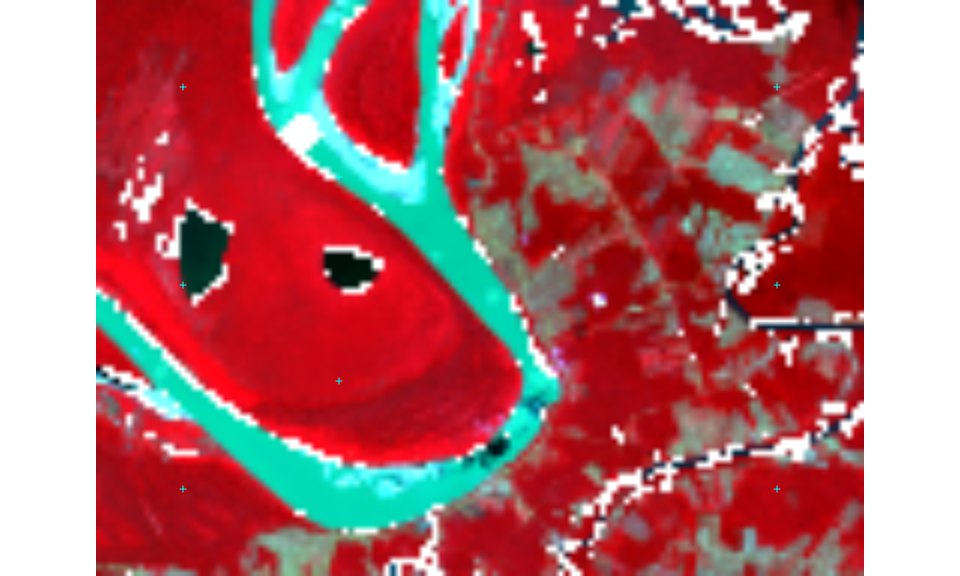

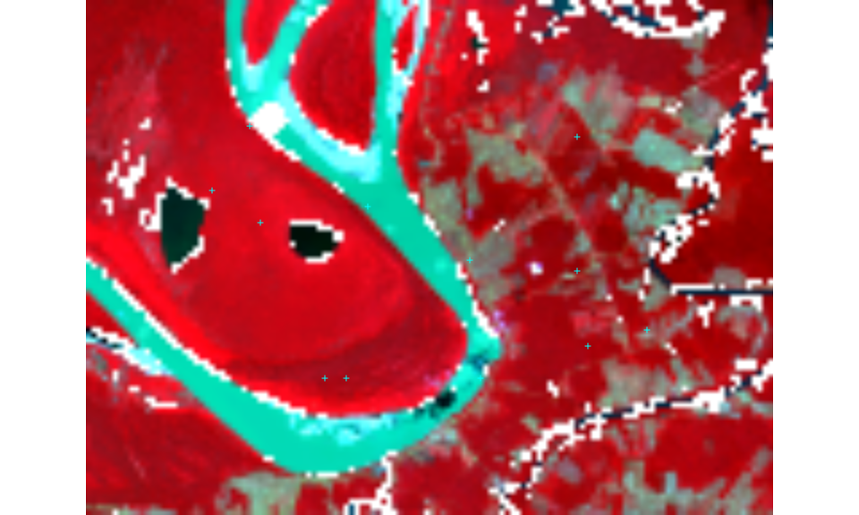

```r
oldpar <- par(mfrow = c(2, 2), mar = c(2.2, 2.2, 2, 0.5))
on.exit(par(oldpar), add = TRUE)
plot_layout <- list(
  list(seeds = seeds_rect, title = "Rectangular"),
  list(seeds = seeds_diamond, title = "Diamond"),
  list(seeds = seeds_hex, title = "Offset grid"),
  list(seeds = seeds_random, title = "Randomised")
)
for (entry in plot_layout) {
  snic_plot(
    s2_demo,
    r = 3, g = 2, b = 1,
    stretch = "lin",
    seeds = entry$seeds,
    seg_plot_args = NULL,
    seeds_plot_args = list(pch = 3, col = "#00FFFF", cex = 0.6),
    main = entry$title
  )
}
```

Random and offset grids inject variability that can better align with elongated features. Once seeds are chosen, each pixel will be assigned to exactly one of them, so the number of segments equals the number of seeds.

## Spacing and padding

Spacing controls seed density; padding keeps seeds away from the borders. Together they influence how detailed the segmentation becomes.

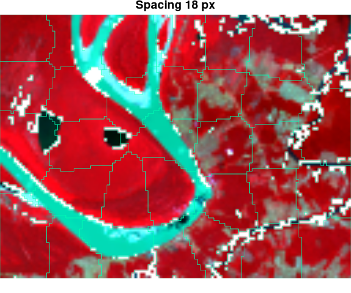

```r
seeds_dense <- snic_grid_rect(s2_demo, spacing = 18L)
seeds_sparse <- snic_grid_rect(s2_demo, spacing = 40L, padding = c(20, 10))

seg_dense <- snic(s2_demo, seeds = seeds_dense, compactness = 0.5)
seg_sparse <- snic(s2_demo, seeds = seeds_sparse, compactness = 0.5)

oldpar <- par(mfrow = c(1, 2), mar = c(2.2, 2.2, 2, 0.5))
on.exit(par(oldpar), add = TRUE)
snic_plot(
  s2_demo,
  r = 3, g = 2, b = 1,
  stretch = "lin",
  seg = seg_dense,
  seg_plot_args = list(border = "#00FFB3", col = NA, lwd = 0.5),
  main = "Spacing 18 px"
)
```

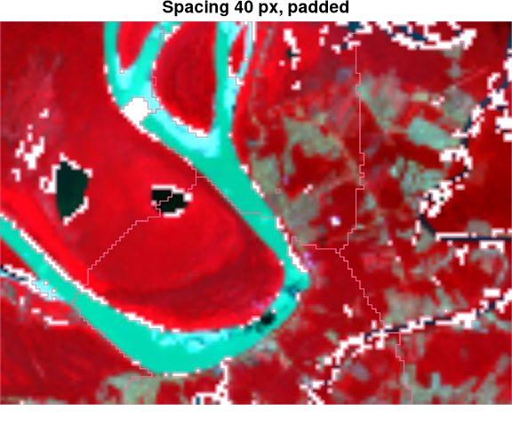

```r
snic_plot(
  s2_demo,
  r = 3, g = 2, b = 1,
  stretch = "lin",
  seg = seg_sparse,
  seg_plot_args = list(border = "#FF6F91", col = NA, lwd = 0.8),
  main = "Spacing 40 px, padded"
)
```

Smaller spacing values create more seeds and therefore finer segments. Larger spacing (or generous padding) reduces the number of segments, which can leave small objects under-segmented near boundaries.

## Under- vs. over-segmentation

- **Over-segmentation** arises when spacing is very small or compactness is close to zero. It produces many tiny superpixels that may complicate later classification.
- **Under-segmentation** happens when spacing is large or compactness is very high. Distinct features may be merged into single segments, biasing summaries.

Visual checks on a few representative areas help pinpoint a spacing/compactness pair that balances those extremes.

## Estimating seed counts in advance

`snic_count_seeds()` reports how many seeds a given spacing/padding combination will generate without constructing the full grid. This makes it easy to aim for a target number of segments.

```r
target_segments <- 450
spacing_candidates <- seq(12, 42, by = 2)
seed_totals <- vapply(
  spacing_candidates,
  function(sp) {
    snic_count_seeds(
      s2_demo,
      spacing = sp,
      padding = sp / 2
    )
  },
  numeric(1)
)
seed_totals <- as.integer(round(seed_totals))
data.frame(
  spacing = spacing_candidates,
  segments = seed_totals
)
```

```
#>    spacing segments
#> 1       12       70
#> 2       14       54
#> 3       16       35
#> 4       18       35
#> 5       20       24
#> 6       22       20
#> 7       24       15
#> 8       26       12
#> 9       28       12
#> 10      30       12
#> 11      32        6
#> 12      34        6
#> 13      36        6
#> 14      38        6
#> 15      40        6
#> 16      42        6
```

```r
best_idx <- which.min(abs(seed_totals - target_segments))
best_spacing <- spacing_candidates[[best_idx]]
best_spacing
```

```
#> [1] 12
```